# BioGVHD project: integration of CyTOF, Metabolomics and RNA features in the Cryostem cohort

Helena

20/04/2020

## Focusing on the recipients

We can first focus on the features that we extracted as informative in the recipients, to see if, taken together, they would be more informative than when working on one data type alone.

### Tolerant versus non tolerant recipients

Since looking at differences between the three groups consisting of primary, secondary and non tolerant patients at the same time wasn’t feasible, we divided our problem in two distinct sub-problems. We first focus on the features that seemed to play a role when trying to disinguish non tolerant from tolerant recipients.

We first need to gather the features that were extracted from the three data sources:

- CyTOF features that were selected in both the St Louis and the Cryostem cohort, with a threshold of 0.90. These features had the same behaviour in both cohorts.
- Metabolomics features that were selected in both the St Louis and the Cryostem cohort, with a threshold of 0.90. These features had the same behaviour in both cohorts.
- Transcriptomics features that were selected in both the St Louis and the Cryostem cohort, with a threshold of 0.90. These features had the same behaviour in both cohorts.

I extract informations on the recipients group, age, gender, … to be able to use this information later on.

```
## [1] 1
```

```
## [1] 1
```

```
##       Gender   HOSPITAL DATEOFCYTOFEXPERIMENT            group gender_comp
## D4147      M CHU Angers            15.09.2017     non_tolerant          MF
## R4147      F CHU Angers            15.09.2017     non_tolerant          MF
## D3574      F CHU Angers            21.09.2017 primary_tolerant          FF
## R3574      F CHU Angers            21.09.2017 primary_tolerant          FF
## D557       F CHU Angers            21.09.2017 primary_tolerant          FF
## R557       F CHU Angers            21.09.2017 primary_tolerant          FF
##       age_recip cmv_comp
## D4147     19529       11
## R4147     19529       11
## D3574     16936       11
## R3574     16936       11
## D557      12009       00
## R557      12009       00
```

I add a prefix (“cyt_”, “rna_” or “met_”) in front of the features names, and I then merge all features together:

[output not shown]

#### Volcano plot analysis

We can do a volcano plot on the CyTOF features, metabolites and genes of the non versus tolerant recipients:

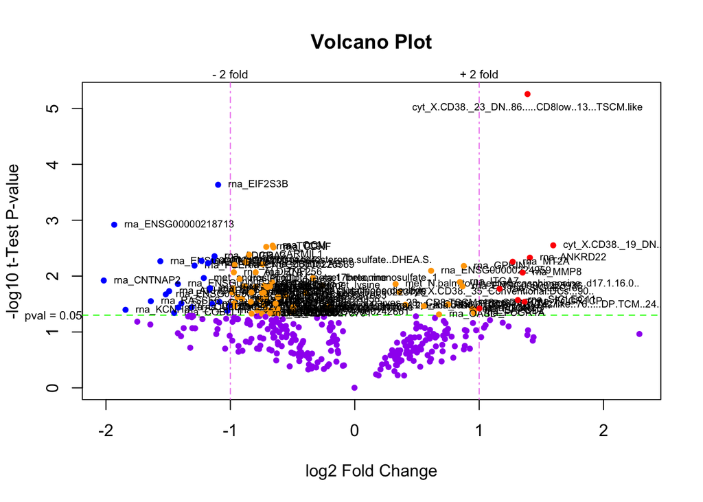

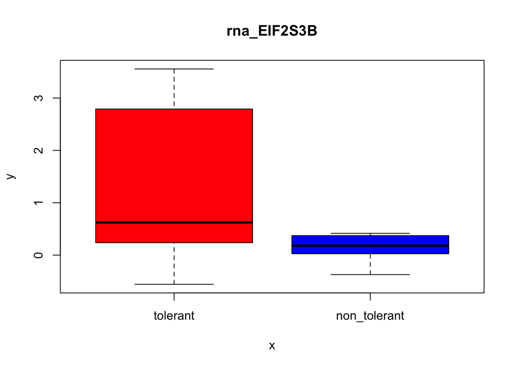

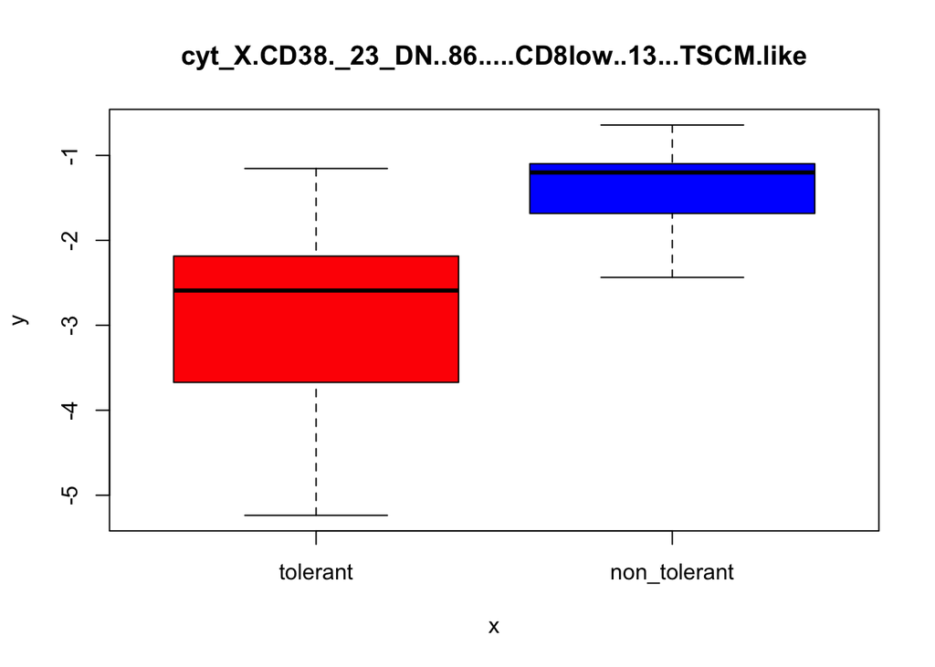

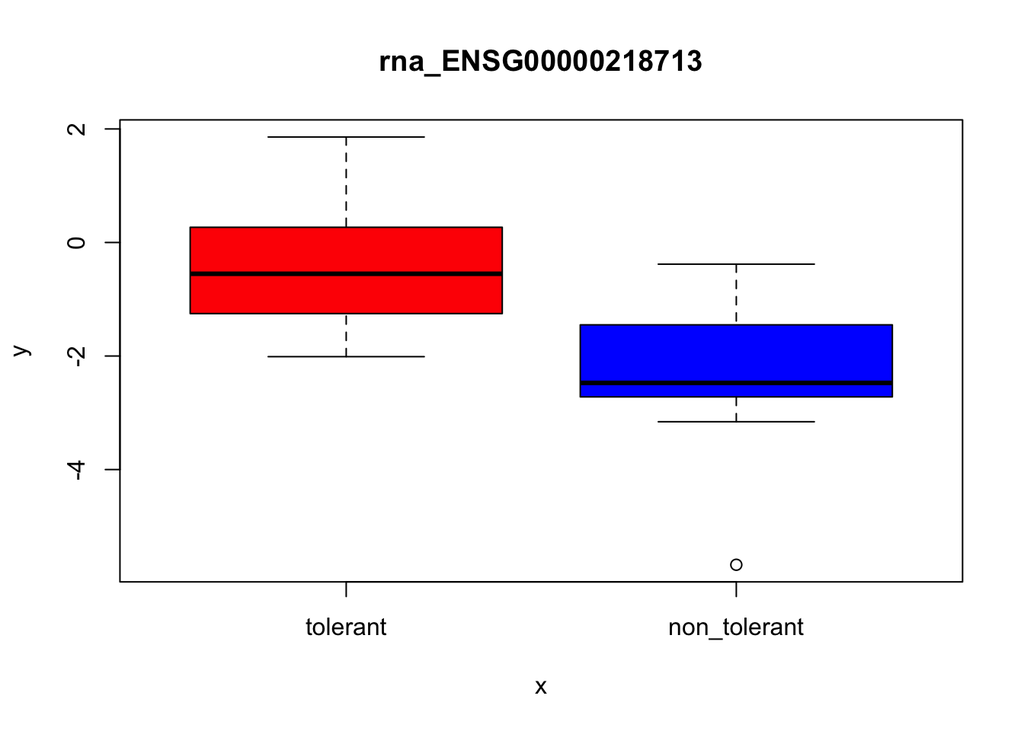

#### Principal component analysis

In the St Louis cohort, we were able to identify a nice separation between the tolerant and non tolerant recipients when integrating the features that we found of interest in the CyTOF, metabolomics and transcriptomics data.

To see if these observations can be confirmed, we will now map the recipients of the Cryostem cohort in the PCA space that was defined by the recipients of the St Louis cohort.

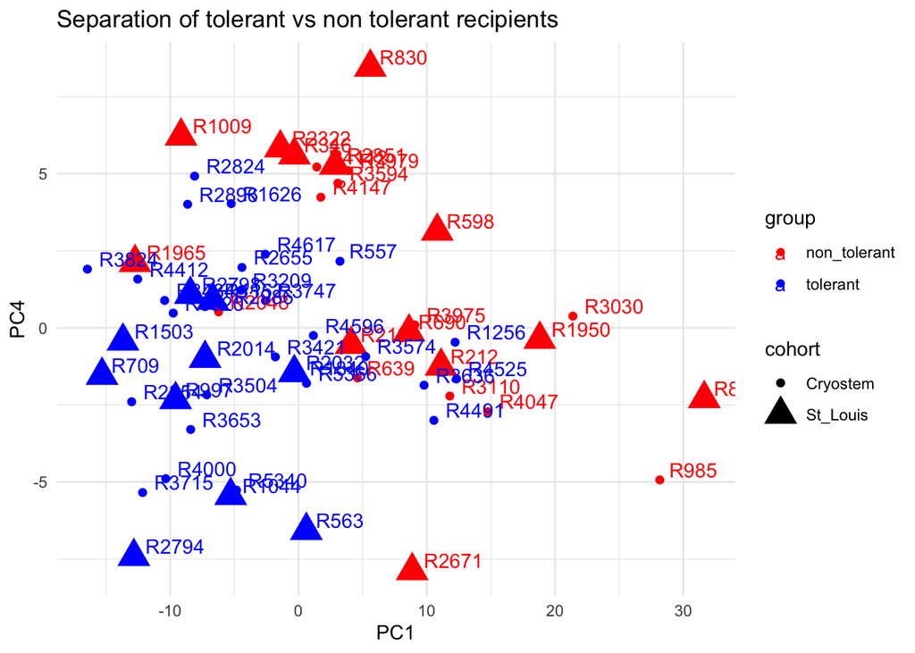

### Primary versus secondary tolerant recipients

We now focus on the features that seemed to play a role when trying to disinguish primary from secondary tolerant recipients.

We first need to gather the features that were extracted from the three data sources:

- CyTOF features that were selected in both the St Louis and the Cryostem cohort, with a threshold of 0.90. These features had the same behaviour in both cohorts.
- Metabolomics features that were selected in both the St Louis and the Cryostem cohort, with a threshold of 0.90. These features had the same behaviour in both cohorts.
- Transcriptomics features that were selected in both the St Louis and the Cryostem cohort, with a threshold of 0.90. These features had the same behaviour in both cohorts.

I extract informations on the recipients group, age, gender, … to be able to use this information later on.

```
## [1] 1
```

```
## [1] 1
```

```
##       Gender   HOSPITAL DATEOFCYTOFEXPERIMENT            group gender_comp
## D4147      M CHU Angers            15.09.2017     non_tolerant          MF
## R4147      F CHU Angers            15.09.2017     non_tolerant          MF
## D3574      F CHU Angers            21.09.2017 primary_tolerant          FF
## R3574      F CHU Angers            21.09.2017 primary_tolerant          FF
## D557       F CHU Angers            21.09.2017 primary_tolerant          FF
## R557       F CHU Angers            21.09.2017 primary_tolerant          FF
##       age_recip cmv_comp
## D4147     19529       11
## R4147     19529       11
## D3574     16936       11
## R3574     16936       11
## D557      12009       00
## R557      12009       00
```

I add a prefix (“cyt_”, “rna_” or “met_”) in front of the features names, and I then merge all features together:

[output not shown]

#### Volcano plot analysis

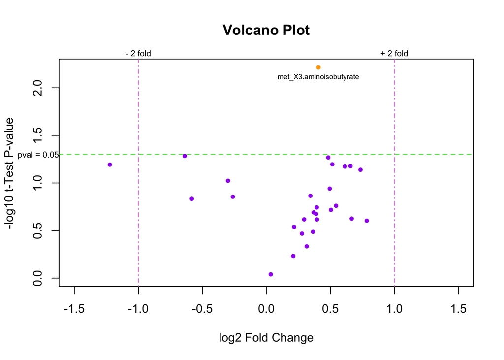

#### Principal component analysis

In the St Louis cohort, we were able to identify a nice separation between primary tolerant and secondary tolerant recipients when integrating the features that we found of interest in the CyTOF, metabolomics and transcriptomics data.

To see if these observations can be confirmed, we will now map the recipients of the Cryostem cohort in the PCA space that was defined by the recipients of the St Louis cohort.

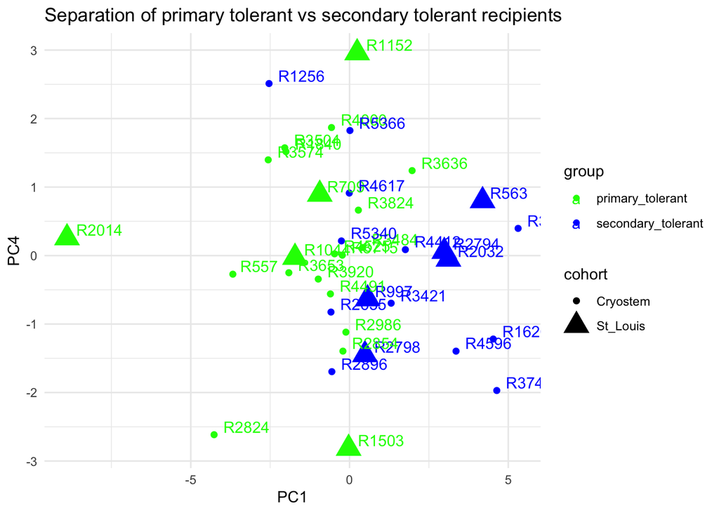

## Adding informations on donors to the recipients

We can then add the features that we extracted as informative in the donors, to see if, taken together, they would be more informative than when working on the integrated data of recipients alone.

### Tolerant versus non tolerant recipients + donors

Since looking at differences between the three groups consisting of primary, secondary and non tolerant patients at the same time wasn’t feasible, we divided our problem in two distinct sub-problems. We first focus on the features that seemed to play a role when trying to disinguish non tolerant from tolerant recipients and donors.

I extract informations on the recipients group, age, gender, … to be able to use this information later on.

```
## [1] 1
```

```
## [1] 1
```

```
##       Gender   HOSPITAL DATEOFCYTOFEXPERIMENT            group gender_comp
## D4147      M CHU Angers            15.09.2017     non_tolerant          MF
## R4147      F CHU Angers            15.09.2017     non_tolerant          MF
## D3574      F CHU Angers            21.09.2017 primary_tolerant          FF
## R3574      F CHU Angers            21.09.2017 primary_tolerant          FF
## D557       F CHU Angers            21.09.2017 primary_tolerant          FF
## R557       F CHU Angers            21.09.2017 primary_tolerant          FF
##       age_recip cmv_comp
## D4147     19529       11
## R4147     19529       11
## D3574     16936       11
## R3574     16936       11
## D557      12009       00
## R557      12009       00
```

We then need to gather the features that were extracted from the three data sources:

- CyTOF features that were selected in both the St Louis and the Cryostem cohort, with a threshold of 0.90. These features had the same behaviour in both cohorts.
- Metabolomics features that were selected in both the St Louis and the Cryostem cohort, with a threshold of 0.90. These features had the same behaviour in both cohorts.
- Transcriptomics features that were selected in both the St Louis and the Cryostem cohort, with a threshold of 0.90. These features had the same behaviour in both cohorts.

I merge all features together:

```
## [1] "We have information on the CyTOF, metabolomics and transcriptomics data for 40 patients in the Cryostem cohort."
```

#### Principal component analysis

In the St Louis cohort, we were able to identify a nice separation between the tolerant and non tolerant recipients when integrating the features that we found of interest in the CyTOF, metabolomics and transcriptomics data.

To see if these observations can be confirmed, we will now map the recipients of the Cryostem cohort in the PCA space that was defined by the recipients of the St Louis cohort.

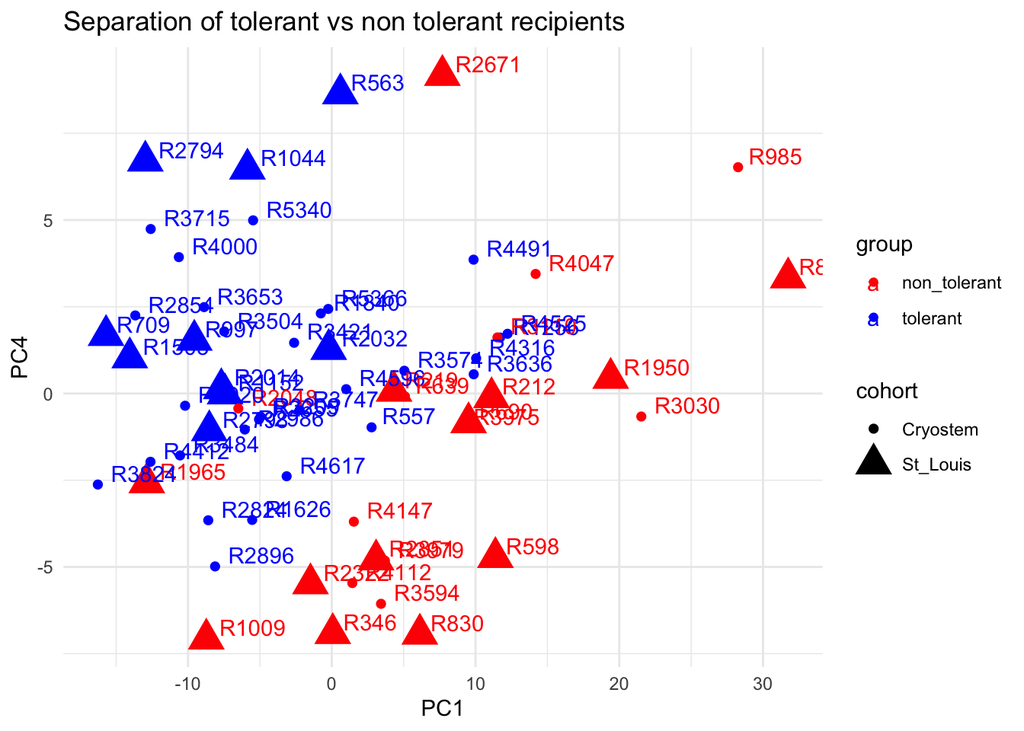

#### Correlations between features

I save the tables corresponding to the features from recipients and donors in the cryostem cohort, to be able to generate correlation plots in the St Louis markdown.

```
## [1]  40 375
```

### Primary tolerant versus secondary tolerant recipients + donors

Since looking at differences between the three groups consisting of primary, secondary and non tolerant patients at the same time wasn’t feasible, we divided our problem in two distinct sub-problems. We now focus on the features that seemed to play a role when trying to disinguish primary tolerant from secondary tolerant recipients using features extracted from recipients and donors.

I extract informations on the recipients group, age, gender, … to be able to use this information later on.

```
## [1] 1
```

```
## [1] 1
```

```
##       Gender   HOSPITAL DATEOFCYTOFEXPERIMENT            group gender_comp
## D4147      M CHU Angers            15.09.2017     non_tolerant          MF
## R4147      F CHU Angers            15.09.2017     non_tolerant          MF
## D3574      F CHU Angers            21.09.2017 primary_tolerant          FF
## R3574      F CHU Angers            21.09.2017 primary_tolerant          FF
## D557       F CHU Angers            21.09.2017 primary_tolerant          FF
## R557       F CHU Angers            21.09.2017 primary_tolerant          FF
##       age_recip cmv_comp
## D4147     19529       11
## R4147     19529       11
## D3574     16936       11
## R3574     16936       11
## D557      12009       00
## R557      12009       00
```

We then need to gather the features that were extracted from the three data sources:

- CyTOF features that were selected in both the St Louis and the Cryostem cohort, with a threshold of 0.90. These features had the same behaviour in both cohorts.
- Metabolomics features that were selected in both the St Louis and the Cryostem cohort, with a threshold of 0.90. These features had the same behaviour in both cohorts.
- Transcriptomics features that were selected in both the St Louis and the Cryostem cohort, with a threshold of 0.90. These features had the same behaviour in both cohorts.

I merge all features together:

```
## [1] "We have information on the CyTOF, metabolomics and transcriptomics data for 29 patients in the Cryostem cohort."
```

#### Principal component analysis

To see if these observations can be confirmed, we will now map the recipients of the Cryostem cohort in the PCA space that was defined by the recipients of the St Louis cohort.

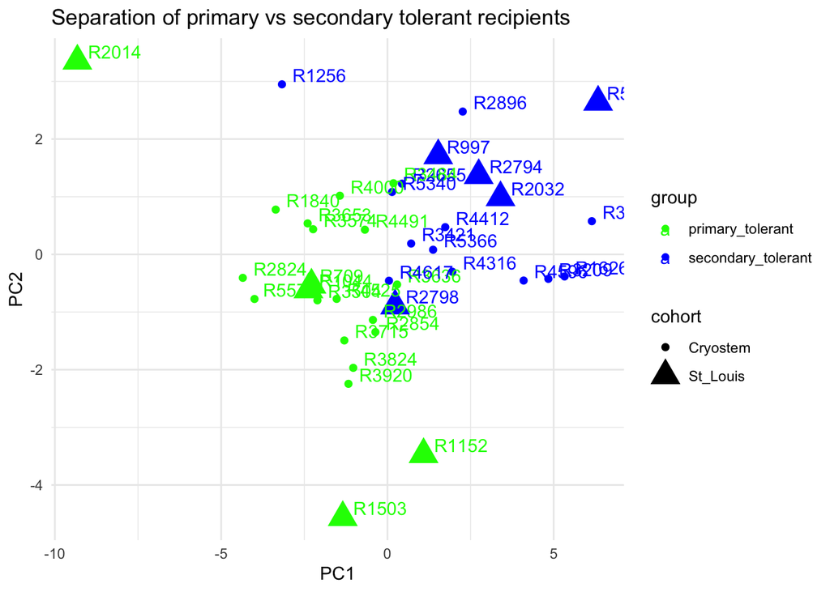

#### Correlations between features

I save the tables corresponding to the features from recipients and donors in the cryostem cohort, to be able to generate correlation plots in the St Louis markdown.

```
## [1] 29 49
```